# Figure S1: Morphology and electrophysiology controls

# Fig S1B

Cumulative distribution of mEPSC event peak amplitudes following homeostatic plasticity.

**Source data**  
`Fig S1B.csv`

**Columns**

- `Date` — Experiment date
- `Condition` — Control or TTX
- `Cell` — Cell ID
- `Peak_Amp` — Signed mEPSC peak amplitude (pA)

## Data

```r
suppressPackageStartupMessages({
  library(dplyr); library(readr); library(ggplot2)
})

Events <- read_csv("./Fig S1B.csv", show_col_types = FALSE) %>%
  transmute(Date = trimws(as.character(Date)), Condition = as.character(Condition),
            Cell = as.character(Cell), Peak_Amp = as.numeric(Peak_Amp)) %>%
  filter(Condition %in% c("Control", "TTX"), is.finite(Peak_Amp)) %>%
  mutate(Condition = factor(Condition, levels = c("Control", "TTX")))

if (n_distinct(Events$Condition) != 2) stop("Both Control and TTX events are required.")
Events %>% mutate(Peak_Amp = round(Peak_Amp, 3))
```

| Date | Condition | Cell | Peak_Amp |
| --- | --- | --- | --- |
| 2025-06-18 | TTX | 3 | -8.091 |
| 2025-06-18 | TTX | 3 | -18.899 |
| 2025-06-18 | TTX | 3 | -11.006 |
| 2025-06-18 | TTX | 3 | -11.937 |
| 2025-06-18 | TTX | 3 | -11.552 |
| 2025-06-18 | TTX | 3 | -13.317 |
| 2025-06-18 | TTX | 3 | -8.490 |
| 2025-06-18 | TTX | 3 | -10.535 |
| 2025-06-18 | TTX | 3 | -5.088 |
| 2025-06-18 | TTX | 3 | -13.355 |

[output cut: 4421 more lines]

## Summary

```r
summary_table <- Events %>% group_by(Condition) %>%
  summarise(n_Events = n(), n_Cells = n_distinct(Date, Cell),
            n_Experiment_Dates = n_distinct(Date), .groups = "drop")
summary_table
```

| Condition | n_Events | n_Cells | n_Experiment_Dates |
| --- | --- | --- | --- |
| Control | 2150 | 10 | 5 |
| TTX | 2281 | 12 | 5 |

## Statistics

Two-sided Kolmogorov–Smirnov test on signed event amplitudes.

```r
ks_result <- ks.test(Events$Peak_Amp[Events$Condition == "Control"],
                     Events$Peak_Amp[Events$Condition == "TTX"])
format_p <- function(p) ifelse(p < 0.0001, "<0.0001", sprintf("%.4f", p))

stats_table <- tibble(
  Test = "Two-sample Kolmogorov-Smirnov test",
  Comparison = "Control vs TTX",
  `KS statistic (D)` = round(unname(ks_result$statistic), 4),
  `p value` = format_p(ks_result$p.value)
)
stats_table
```

| Test | Comparison | KS statistic (D) | p value |
| --- | --- | --- | --- |
| Two-sample Kolmogorov-Smirnov test | Control vs TTX | 0.1537 | <0.0001 |

## Plot

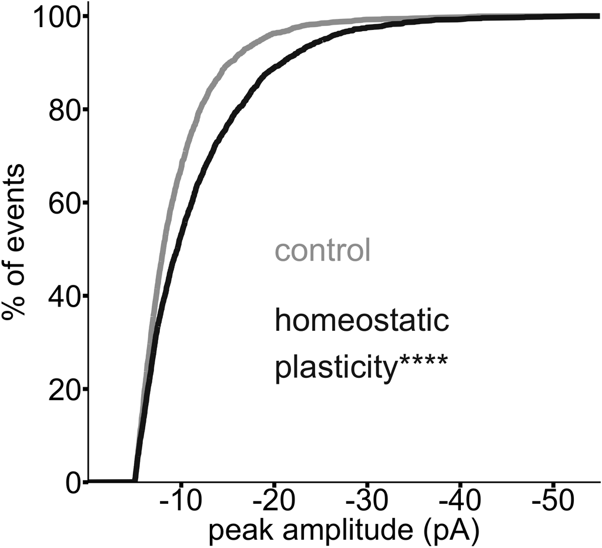

```r
set.seed(20261109)
figs1b_plot <- ggplot(Events, aes(Peak_Amp, color = Condition)) +
  stat_ecdf(geom = "line", linewidth = 7) +
  annotate("text", x = -20, y = 0.5, label = "control",
           color = "#9E9E9E", hjust = 0, size = 30) +
  annotate("text", x = -20, y = 0.3, label = paste0("homeostatic\nplasticity", ifelse(ks_result$p.value < 0.0001,"****",ifelse(ks_result$p.value < 0.001,"***",ifelse(ks_result$p.value < 0.01,"**",ifelse(ks_result$p.value < 0.05,"*","ns"))))),
           color = "#1A1A1A", hjust = 0, size = 30) +
  scale_x_reverse(oob = scales::oob_keep, limits = c(0, -55), breaks = seq(-10, -50, by = -10),
                expand = c(0, 0)) +
  scale_y_continuous(oob = scales::oob_keep, limits = c(0, 1.03), breaks = seq(0, 1, 0.2),
                     labels = function(x) x * 100, expand = c(0, 0)) +
  scale_color_manual(values = c(Control = "#9E9E9E", TTX = "#1A1A1A")) +
  labs(x = "peak amplitude (pA)", y = "% of events") +
  theme_classic() +
  theme(axis.title = element_text(size = 80, color = "black"),
        axis.text = element_text(size = 80, color = "black"),
        axis.ticks = element_line(linewidth = 5, color = "black"),
        axis.ticks.length = grid::unit(0.5, "cm"),
        axis.line = element_line(linewidth = 2, color = "black"),
        legend.position = "none")
figs1b_plot
```

# Fig S1C

Mean spine area per cell following homeostatic plasticity.

**update for 2026 pending** — The analysis includes 43 treated cells. The v3 legend reports 45.

**Source data**  
`Fig S1C.csv`

**Columns**

- `Date` — Experiment date
- `Condition` — Control or TTX
- `Dish` — Culture dish ID
- `Cell` — Cell ID
- `spine_area_um2` — Mean spine area per cell (µm²)

## Data

```r
suppressPackageStartupMessages({
  library(dplyr); library(readr); library(ggplot2); library(ggtext)
})

spacing_map <- c(Control = 1, TTX = 2.2)
spine_df <- read_csv("./Fig S1C.csv", show_col_types = FALSE) %>%
  select(Date, Condition, Dish, Cell, spine_area_um2) %>%
  mutate(Condition = trimws(as.character(Condition)),
         Condition = case_when(grepl("^Control", Condition, ignore.case = TRUE) ~ "Control",
                               grepl("^TTX", Condition, ignore.case = TRUE) ~ "TTX",
                               TRUE ~ Condition),
         Date = trimws(as.character(Date)),
         spine_area_um2 = as.numeric(spine_area_um2)) %>%
  filter(Condition %in% names(spacing_map), Date != "", is.finite(spine_area_um2)) %>%
  mutate(Condition = factor(Condition, levels = names(spacing_map)),
         Date = factor(Date), Date_Condition = paste(Condition, Date, sep = "_"),
         x_pos = unname(spacing_map[as.character(Condition)]))

if (n_distinct(spine_df$Condition) < 2 || n_distinct(spine_df$Date) < 2)
  stop("Both conditions and at least two dates are required.")

spine_df %>%
  select(Date, Condition, Dish, Cell, spine_area_um2) %>%
  mutate(spine_area_um2 = round(spine_area_um2, 3))
```

| Date | Condition | Dish | Cell | spine_area_um2 |
| --- | --- | --- | --- | --- |
| 2022-10-08 | Control | 1 | 1 | 0.375 |
| 2022-10-08 | Control | 1 | 2 | 0.392 |
| 2022-10-08 | Control | 1 | 3 | 0.455 |
| 2022-10-08 | Control | 1 | 4 | 0.420 |
| 2022-10-08 | Control | 1 | 5 | 0.366 |
| 2022-10-08 | Control | 1 | 6 | 0.348 |
| 2022-10-08 | Control | 2 | 1 | 0.393 |
| 2022-10-08 | Control | 2 | 2 | 0.460 |
| 2022-10-08 | Control | 2 | 3 | 0.266 |
| 2022-10-08 | Control | 2 | 4 | 0.285 |

[output cut: 74 more lines]

## Summary

```r
summary_table <- spine_df %>% group_by(Condition) %>%
  summarise(n_Cells = n_distinct(Date, Dish, Cell), n_Experiment_Dates = n_distinct(Date),
            `Mean (SE)` = sprintf("%.3f (%.3f)", mean(spine_area_um2),
                                  sd(spine_area_um2) / sqrt(n())), .groups = "drop")
summary_table
```

| Condition | n_Cells | n_Experiment_Dates | Mean (SE) |
| --- | --- | --- | --- |
| Control | 41 | 3 | 0.390 (0.012) |
| TTX | 43 | 3 | 0.482 (0.017) |

## Statistics

Two-way ANOVA with condition, experiment date, and their interaction (Type I sums of squares).

```r
fit_aov <- aov(spine_area_um2 ~ Condition * Date, data = spine_df)
condition_p <- as.numeric(anova(fit_aov)["Condition", "Pr(>F)"])
format_p <- function(p) ifelse(p < 0.0001, "<0.0001", sprintf("%.4f", p))

stats_table <- tibble(
  Test = "Two-way ANOVA", Comparison = "Control vs TTX",
  `Control mean (SE)` = summary_table$`Mean (SE)`[summary_table$Condition == "Control"],
  `TTX mean (SE)` = summary_table$`Mean (SE)`[summary_table$Condition == "TTX"],
  `Condition p` = format_p(condition_p)
)
stats_table
```

| Test | Comparison | Control mean (SE) | TTX mean (SE) | Condition p |
| --- | --- | --- | --- | --- |
| Two-way ANOVA | Control vs TTX | 0.390 (0.012) | 0.482 (0.017) | <0.0001 |

```r
anova(fit_aov)
```

|  | Df | Sum Sq | Mean Sq | F value | Pr(>F) |
| --- | --- | --- | --- | --- | --- |
| Condition | 1 | 0.176947350 | 0.176947350 | 20.8078396 | 1.858574e-05 |
| Date | 2 | 0.089235228 | 0.044617614 | 5.2467367 | 7.280330e-03 |
| Condition:Date | 2 | 0.003425673 | 0.001712836 | 0.2014182 | 8.179943e-01 |
| Residuals | 78 | 0.663302559 | 0.008503879 | NA | NA |

## Plot

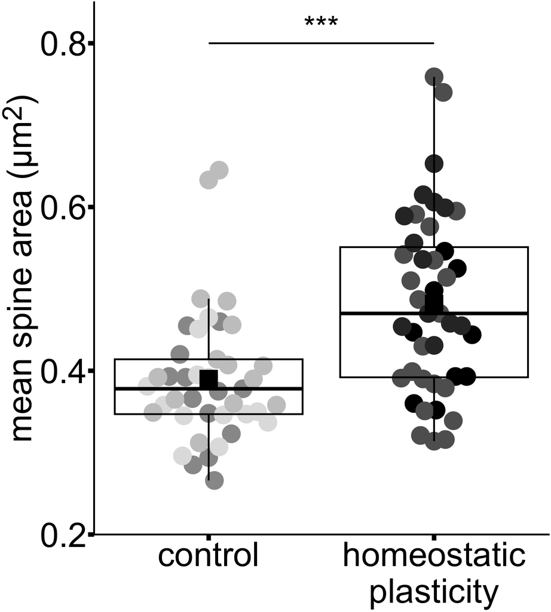

```r
set.seed(20261109)
date_levels <- levels(spine_df$Date)
date_colors <- c(
  setNames(rep(c("#999999", "#E0E0E0", "#C8C8C8"), length.out = length(date_levels)),
           paste("Control", date_levels, sep = "_")),
  setNames(rep(c("#000000", "#606060", "#303030"), length.out = length(date_levels)),
           paste("TTX", date_levels, sep = "_"))
)

test_results <- tibble(
  group1_x = spacing_map["Control"], group2_x = spacing_map["TTX"],
  y_position = 0.8,
  stars = case_when(condition_p < 0.001 ~ "***", condition_p < 0.01 ~ "**",
                    condition_p < 0.05 ~ "*", TRUE ~ "ns")
)

figs1c_plot <- ggplot(spine_df, aes(x_pos, spine_area_um2, color = Date_Condition)) +
  ggbeeswarm::geom_beeswarm(cex = 5, priority = "random", size = 20, corral = "random") +
  geom_boxplot(aes(group = x_pos), fill = NA, width = 1, outlier.shape = NA,
               linewidth = 2, color = "black") +
  stat_summary(aes(group = x_pos), fun = mean, geom = "point",
               shape = 15, size = 20, color = "black") +
  geom_segment(data = test_results,
               aes(x = group1_x, xend = group2_x, y = y_position, yend = y_position),
               inherit.aes = FALSE, linewidth = 2, color = "black") +
  geom_text(data = test_results,
            aes(x = (group1_x + group2_x) / 2, y = y_position + 0.02, label = stars),
            inherit.aes = FALSE, size = 25, color = "black") +
  scale_x_continuous(breaks = unname(spacing_map),
                     labels = c("control", "homeostatic\nplasticity")) +
  scale_color_manual(values = date_colors) +
  scale_y_continuous(oob = scales::oob_keep, breaks = c(0.2, 0.4, 0.6, 0.8),
                     limits = c(0.2, 0.85), expand = c(0, 0)) +
  labs(x = NULL, y = "mean spine area (&micro;m<sup>2</sup>)") +
  theme_classic() +
  theme(axis.title.y = ggtext::element_markdown(size = 80, color = "black"),
        axis.text = element_text(size = 80, color = "black"),
        axis.ticks = element_line(linewidth = 5, color = "black"),
        axis.ticks.length = grid::unit(0.5, "cm"),
        axis.line = element_line(linewidth = 2, color = "black"),
        legend.position = "none")
figs1c_plot
```

# Fig S1D

Mean dendritic mitochondrial length following homeostatic plasticity.

**Source data**  
`Fig S1D.csv`

**Columns**

- `Date` — Experiment date
- `Condition` — Control or TTX
- `Cell` — Cell ID
- `mean_mito_len` — Mean mitochondrial length per cell (µm)

## Data

```r
suppressPackageStartupMessages({
  library(dplyr); library(readr); library(ggplot2); library(ggbeeswarm)
})

spacing_map <- c(Control = 1, TTX = 2.2)
mito_df <- read_csv("./Fig S1D.csv", show_col_types = FALSE) %>%
  select(Date, Condition, Cell, mean_mito_len) %>%
  mutate(Date = trimws(as.character(Date)), Condition = trimws(as.character(Condition)),
         mean_mito_len = as.numeric(mean_mito_len)) %>%
  filter(Condition %in% names(spacing_map), Date != "", is.finite(mean_mito_len)) %>%
  mutate(Date = factor(Date), Condition = factor(Condition, levels = names(spacing_map)),
         Date_Condition = paste(Condition, Date, sep = "_"),
         x_pos = unname(spacing_map[as.character(Condition)]))

if (n_distinct(mito_df$Condition) < 2 || n_distinct(mito_df$Date) < 2)
  stop("Both conditions and at least two dates are required.")

mito_df %>% select(Date, Condition, Cell, mean_mito_len) %>%
  mutate(mean_mito_len = round(mean_mito_len, 3))
```

| Date | Condition | Cell | mean_mito_len |
| --- | --- | --- | --- |
| 2022-10-08 | Control | 1 | 6.724 |
| 2022-10-08 | Control | 2 | 6.008 |
| 2022-10-08 | Control | 3 | 5.374 |
| 2022-10-08 | Control | 4 | 5.296 |
| 2022-10-08 | Control | 5 | 8.438 |
| 2022-10-08 | Control | 6 | 9.718 |
| 2022-10-08 | Control | 7 | 8.286 |
| 2022-10-08 | Control | 8 | 8.032 |
| 2022-10-08 | Control | 9 | 7.032 |
| 2022-10-08 | Control | 10 | 9.974 |

[output cut: 76 more lines]

## Summary

```r
summary_table <- mito_df %>% group_by(Condition) %>%
  summarise(n_Observations = n(), n_Cells = n_distinct(Date, Cell),
            n_Experiment_Dates = n_distinct(Date),
            `Mean (SE)` = sprintf("%.3f (%.3f)", mean(mean_mito_len),
                                  sd(mean_mito_len) / sqrt(n())), .groups = "drop")
summary_table
```

| Condition | n_Observations | n_Cells | n_Experiment_Dates | Mean (SE) |
| --- | --- | --- | --- | --- |
| Control | 41 | 41 | 3 | 9.216 (0.602) |
| TTX | 45 | 45 | 3 | 13.014 (1.101) |

## Statistics

Two-way ANOVA with condition, experiment date, and their interaction (Type I sums of squares).

```r
fit_aov <- aov(mean_mito_len ~ Condition * Date, data = mito_df)
condition_p <- as.numeric(anova(fit_aov)["Condition", "Pr(>F)"])
format_p <- function(p) ifelse(p < 0.0001, "<0.0001", sprintf("%.4f", p))

stats_table <- tibble(
  Test = "Two-way ANOVA", Comparison = "Control vs TTX",
  `Control mean (SE)` = summary_table$`Mean (SE)`[summary_table$Condition == "Control"],
  `TTX mean (SE)` = summary_table$`Mean (SE)`[summary_table$Condition == "TTX"],
  `Condition p` = format_p(condition_p)
)
stats_table
```

| Test | Comparison | Control mean (SE) | TTX mean (SE) | Condition p |
| --- | --- | --- | --- | --- |
| Two-way ANOVA | Control vs TTX | 9.216 (0.602) | 13.014 (1.101) | 0.0029 |

```r
anova(fit_aov)
```

|  | Df | Sum Sq | Mean Sq | F value | Pr(>F) |
| --- | --- | --- | --- | --- | --- |
| Condition | 1 | 309.3899 | 309.38990 | 9.456139 | 0.002879046 |
| Date | 2 | 250.3851 | 125.19255 | 3.826363 | 0.025881076 |
| Condition:Date | 2 | 127.8483 | 63.92413 | 1.953766 | 0.148443622 |
| Residuals | 80 | 2617.4733 | 32.71842 | NA | NA |

## Plot

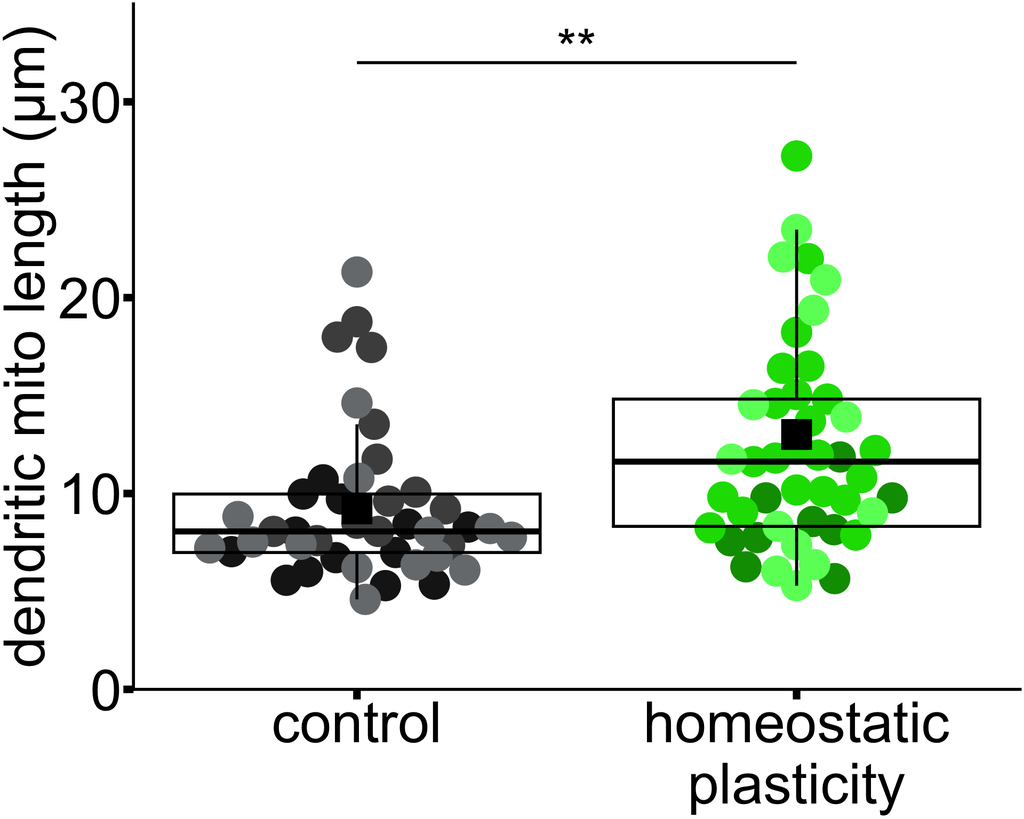

```r
set.seed(20261109)
date_levels <- levels(mito_df$Date)
date_colors <- c(
  setNames(rep(c("#1A1A1A", "#4D4D4D", "#777B7E"), length.out = length(date_levels)),
           paste("Control", date_levels, sep = "_")),
  setNames(rep(c("#009A00", "#00DC00", "#66FF66"), length.out = length(date_levels)),
           paste("TTX", date_levels, sep = "_"))
)
test_results <- tibble(
  group1_x = spacing_map["Control"], group2_x = spacing_map["TTX"], y_position = 32,
  stars = case_when(condition_p < 0.001 ~ "***", condition_p < 0.01 ~ "**",
                    condition_p < 0.05 ~ "*", TRUE ~ "ns")
)

figs1d_plot <- ggplot(mito_df, aes(x_pos, mean_mito_len, color = Date_Condition)) +
  ggbeeswarm::geom_beeswarm(cex = 5, priority = "random", size = 20, corral = "random") +
  geom_boxplot(aes(group = x_pos), fill = NA, width = 1, outlier.shape = NA,
               linewidth = 2, color = "black") +
  stat_summary(aes(group = x_pos), fun = mean, geom = "point",
               shape = 15, size = 20, color = "black") +
  geom_segment(data = test_results,
               aes(x = group1_x, xend = group2_x, y = y_position, yend = y_position),
               inherit.aes = FALSE, linewidth = 2, color = "black") +
  geom_text(data = test_results,
            aes(x = (group1_x + group2_x) / 2, y = y_position + 0.8, label = stars),
            inherit.aes = FALSE, size = 25, color = "black") +
  scale_x_continuous(breaks = unname(spacing_map),
                     labels = c("control", "homeostatic\nplasticity")) +
  scale_color_manual(values = date_colors) +
  scale_y_continuous(oob = scales::oob_keep, breaks = c(0, 10, 20, 30),
                     limits = c(0, 35), expand = c(0, 0)) +
  labs(x = NULL, y = "dendritic mito length (µm)") +
  theme_classic() +
  theme(axis.title = element_text(size = 80, color = "black"),
        axis.text = element_text(size = 80, color = "black"),
        axis.ticks = element_line(linewidth = 5, color = "black"),
        axis.ticks.length = grid::unit(0.5, "cm"),
        axis.line = element_line(linewidth = 2, color = "black"),
        legend.position = "none")
figs1d_plot
```

# Fig S1E

Mean axonal mitochondrial length following homeostatic plasticity.

**Source data**  
`Fig S1E.csv`

**Columns**

- `Date` — Experiment date
- `Condition` — Control or TTX
- `Dish` — Culture dish ID
- `Cell` — Cell ID
- `mito_length_um` — Axonal mitochondrial length per cell (µm)

## Data

```r
suppressPackageStartupMessages({
  library(dplyr); library(readr); library(ggplot2); library(ggbeeswarm); library(ggtext)
})

spacing_map <- c(Control = 1, TTX = 2.2)
mito_df <- read_csv("./Fig S1E.csv", show_col_types = FALSE) %>%
  select(Date, Condition, Dish, Cell, mito_length_um) %>%
  mutate(Date = trimws(as.character(Date)), Condition = trimws(as.character(Condition)),
         mito_length_um = as.numeric(mito_length_um)) %>%
  filter(Condition %in% names(spacing_map), Date != "", is.finite(mito_length_um)) %>%
  mutate(Date = factor(Date), Condition = factor(Condition, levels = names(spacing_map)),
         Date_Condition = paste(Condition, Date, sep = "_"),
         x_pos = unname(spacing_map[as.character(Condition)]))

if (n_distinct(mito_df$Condition) < 2 || n_distinct(mito_df$Date) < 2)
  stop("Both conditions and at least two dates are required.")

mito_df %>% select(Date, Condition, Dish, Cell, mito_length_um) %>%
  mutate(mito_length_um = round(mito_length_um, 3))
```

| Date | Condition | Dish | Cell | mito_length_um |
| --- | --- | --- | --- | --- |
| 2022-10-08 | Control | 1 | 1 | 0.913 |
| 2022-10-08 | Control | 1 | 2 | 0.739 |
| 2022-10-08 | Control | 1 | 3 | 0.884 |
| 2022-10-08 | Control | 1 | 4 | 0.761 |
| 2022-10-08 | Control | 1 | 5 | 0.980 |
| 2022-10-08 | Control | 1 | 6 | 0.613 |
| 2022-10-08 | Control | 2 | 1 | 0.686 |
| 2022-10-08 | Control | 2 | 2 | 0.768 |
| 2022-10-08 | Control | 2 | 3 | 0.759 |
| 2022-10-08 | Control | 2 | 4 | 0.930 |

[output cut: 76 more lines]

## Summary

```r
summary_table <- mito_df %>% group_by(Condition) %>%
  summarise(n_Mitochondria = n(), n_Cells = n_distinct(Date, Dish, Cell),
            n_Experiment_Dates = n_distinct(Date),
            `Mean (SE)` = sprintf("%.3f (%.3f)", mean(mito_length_um),
                                  sd(mito_length_um) / sqrt(n())), .groups = "drop")
summary_table
```

| Condition | n_Mitochondria | n_Cells | n_Experiment_Dates | Mean (SE) |
| --- | --- | --- | --- | --- |
| Control | 41 | 41 | 3 | 0.715 (0.024) |
| TTX | 45 | 45 | 3 | 0.673 (0.033) |

## Statistics

Two-way ANOVA with condition, experiment date, and their interaction (Type I sums of squares).

```r
fit_aov <- aov(mito_length_um ~ Condition * Date, data = mito_df)
condition_p <- as.numeric(anova(fit_aov)["Condition", "Pr(>F)"])
format_p <- function(p) ifelse(p < 0.0001, "<0.0001", sprintf("%.4f", p))

stats_table <- tibble(
  Test = "Two-way ANOVA", Comparison = "Control vs TTX",
  `Control mean (SE)` = summary_table$`Mean (SE)`[summary_table$Condition == "Control"],
  `TTX mean (SE)` = summary_table$`Mean (SE)`[summary_table$Condition == "TTX"],
  `Condition p` = format_p(condition_p)
)
stats_table
```

| Test | Comparison | Control mean (SE) | TTX mean (SE) | Condition p |
| --- | --- | --- | --- | --- |
| Two-way ANOVA | Control vs TTX | 0.715 (0.024) | 0.673 (0.033) | 0.3187 |

```r
anova(fit_aov)
```

|  | Df | Sum Sq | Mean Sq | F value | Pr(>F) |
| --- | --- | --- | --- | --- | --- |
| Condition | 1 | 0.03831955 | 0.03831955 | 1.0068592 | 0.3186819 |
| Date | 2 | 0.07108891 | 0.03554446 | 0.9339425 | 0.3972433 |
| Condition:Date | 2 | 0.08021055 | 0.04010527 | 1.0537796 | 0.3534059 |
| Residuals | 80 | 3.04468028 | 0.03805850 | NA | NA |

## Plot

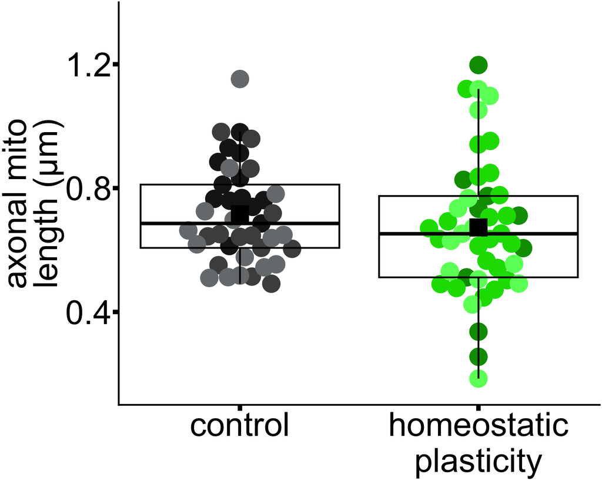

```r
set.seed(20261109)
date_levels <- levels(mito_df$Date)
date_colors <- c(
  setNames(rep(c("#1A1A1A", "#4D4D4D", "#777B7E"), length.out = length(date_levels)),
           paste("Control", date_levels, sep = "_")),
  setNames(rep(c("#009A00", "#00DC00", "#66FF66"), length.out = length(date_levels)),
           paste("TTX", date_levels, sep = "_"))
)
test_results <- tibble(
  group1_x = spacing_map["Control"], group2_x = spacing_map["TTX"], y_position = 1.25,
  stars = case_when(condition_p < 0.001 ~ "***", condition_p < 0.01 ~ "**",
                    condition_p < 0.05 ~ "*", TRUE ~ "ns")
) %>% filter(stars != "ns")

figs1e_plot <- ggplot(mito_df, aes(x_pos, mito_length_um, color = Date_Condition)) +
  ggbeeswarm::geom_beeswarm(cex = 5, priority = "random", size = 20, corral = "random") +
  geom_boxplot(aes(group = x_pos), fill = NA, width = 1, outlier.shape = NA,
               linewidth = 2, color = "black") +
  stat_summary(aes(group = x_pos), fun = mean, geom = "point",
               shape = 15, size = 20, color = "black") +
  geom_segment(data = test_results,
               aes(x = group1_x, xend = group2_x, y = y_position, yend = y_position),
               inherit.aes = FALSE, linewidth = 2, color = "black") +
  geom_text(data = test_results,
            aes(x = (group1_x + group2_x) / 2, y = y_position + 0.05, label = stars),
            inherit.aes = FALSE, size = 25, color = "black") +
  scale_x_continuous(breaks = unname(spacing_map),
                     labels = c("control", "homeostatic\nplasticity")) +
  scale_color_manual(values = date_colors) +
  scale_y_continuous(oob = scales::oob_keep, breaks = c(0.4, 0.8, 1.2),
                     limits = c(0.1, 1.4), expand = c(0, 0)) +
  labs(x = NULL, y = "axonal mito<br>length (&micro;m)") +
  theme_classic() +
  theme(axis.title.y = ggtext::element_markdown(size = 80, color = "black"),
        axis.text = element_text(size = 80, color = "black"),
        axis.ticks = element_line(linewidth = 5, color = "black"),
        axis.ticks.length = grid::unit(0.5, "cm"),
        axis.line = element_line(linewidth = 2, color = "black"),
        legend.position = "none")
figs1e_plot
```

# Fig S1F

Dendritic mitochondrial length with imaging performed in the continued presence of TTX.

**Source data**  
`Fig S1F, G.csv`

**Columns**

- `Date` — Experiment date
- `Condition` — Control or TTX with TTX maintained during imaging
- `Cell` — Cell ID
- `mean_mito_len` — Mean mitochondrial length per cell (µm)

## Data

```r
suppressPackageStartupMessages({
  library(dplyr); library(readr); library(ggplot2); library(ggbeeswarm); library(ggtext)
})

spacing_map <- c(Control = 1, TTXinTTX = 2.2)
mito_df <- read_csv("./Fig S1F, G.csv", show_col_types = FALSE) %>%
  select(Date, Condition, Cell, mean_mito_len) %>%
  mutate(Date = trimws(as.character(Date)), Condition = trimws(as.character(Condition)),
         Condition = case_when(grepl("^Control", Condition, ignore.case = TRUE) ~ "Control",
                               grepl("^TTXinTTX", Condition, ignore.case = TRUE) ~ "TTXinTTX",
                               TRUE ~ Condition),
         mean_mito_len = as.numeric(mean_mito_len)) %>%
  filter(Condition %in% names(spacing_map), Date != "", !is.na(Cell),
         is.finite(mean_mito_len)) %>%
  mutate(Date = factor(Date), Condition = factor(Condition, levels = names(spacing_map)),
         Date_Condition = paste(Condition, Date, sep = "_"),
         x_pos = unname(spacing_map[as.character(Condition)]))

if (n_distinct(mito_df$Condition) < 2 || n_distinct(mito_df$Date) < 2)
  stop("Both conditions and at least two dates are required.")

mito_df %>% select(Date, Condition, Cell, mean_mito_len) %>%
  mutate(mean_mito_len = round(mean_mito_len, 3))
```

| Date | Condition | Cell | mean_mito_len |
| --- | --- | --- | --- |
| 2025-06-18 | Control | 1 | 6.068 |
| 2025-06-18 | Control | 5 | 9.227 |
| 2025-06-18 | Control | 6 | 10.052 |
| 2025-06-18 | Control | 7 | 4.535 |
| 2025-06-18 | Control | 8 | 5.131 |
| 2025-06-18 | Control | 9 | 4.812 |
| 2025-06-18 | Control | 2 | 6.057 |
| 2025-06-18 | Control | 3 | 4.849 |
| 2025-06-18 | Control | 4 | 9.517 |
| 2025-06-18 | TTXinTTX | 10 | 6.509 |

[output cut: 26 more lines]

## Summary

```r
summary_table <- mito_df %>% group_by(Condition) %>%
  summarise(n_Cells = n_distinct(Date, Cell), n_Experiment_Dates = n_distinct(Date),
            `Mean (SE)` = sprintf("%.3f (%.3f)", mean(mean_mito_len),
                                  sd(mean_mito_len) / sqrt(n())), .groups = "drop")
summary_table
```

| Condition | n_Cells | n_Experiment_Dates | Mean (SE) |
| --- | --- | --- | --- |
| Control | 17 | 2 | 5.819 (0.474) |
| TTXinTTX | 19 | 2 | 7.230 (0.500) |

## Statistics

Two-way ANOVA with condition, experiment date, and their interaction (Type I sums of squares).

```r
fit_aov <- aov(mean_mito_len ~ Condition * Date, data = mito_df)
condition_p <- as.numeric(anova(fit_aov)["Condition", "Pr(>F)"])
format_p <- function(p) ifelse(p < 0.0001, "<0.0001", sprintf("%.4f", p))

stats_table <- tibble(
  Test = "Two-way ANOVA", Comparison = "Control vs TTXinTTX",
  `Control mean (SE)` = summary_table$`Mean (SE)`[summary_table$Condition == "Control"],
  `TTXinTTX mean (SE)` = summary_table$`Mean (SE)`[summary_table$Condition == "TTXinTTX"],
  `Condition p` = format_p(condition_p)
)
stats_table
```

| Test | Comparison | Control mean (SE) | TTXinTTX mean (SE) | Condition p |
| --- | --- | --- | --- | --- |
| Two-way ANOVA | Control vs TTXinTTX | 5.819 (0.474) | 7.230 (0.500) | 0.0357 |

```r
anova(fit_aov)
```

|  | Df | Sum Sq | Mean Sq | F value | Pr(>F) |
| --- | --- | --- | --- | --- | --- |
| Condition | 1 | 17.877100 | 17.877100 | 4.8079969 | 0.03571384 |
| Date | 1 | 26.769067 | 26.769067 | 7.1994671 | 0.01144598 |
| Condition:Date | 1 | 0.870719 | 0.870719 | 0.2341775 | 0.63173878 |
| Residuals | 32 | 118.982436 | 3.718201 | NA | NA |

## Plot

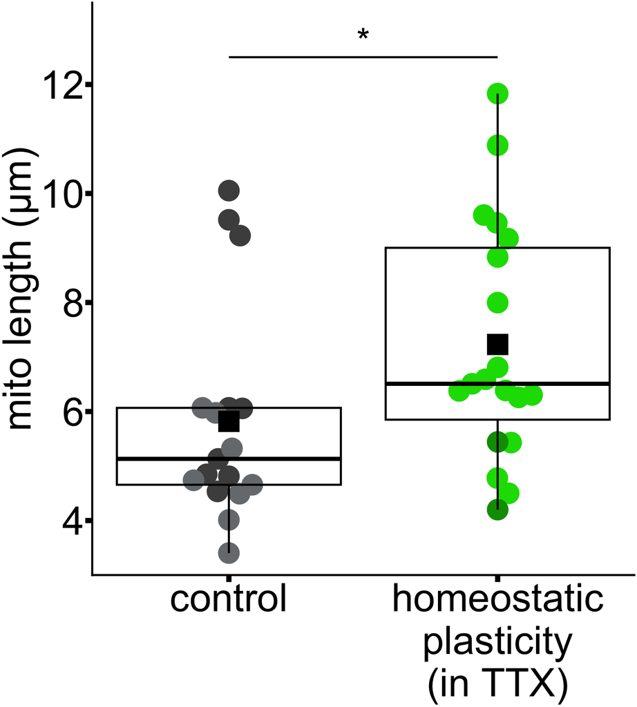

```r
set.seed(20261109)
date_levels <- levels(mito_df$Date)
date_colors <- c(
  setNames(rep(c("#4D4D4D", "#777B7E", "#1A1A1A"), length.out = length(date_levels)),
           paste("Control", date_levels, sep = "_")),
  setNames(rep(c("#00DC00", "#009A00", "#66FF66"), length.out = length(date_levels)),
           paste("TTXinTTX", date_levels, sep = "_"))
)
test_results <- tibble(
  group1_x = spacing_map["Control"], group2_x = spacing_map["TTXinTTX"],
  y_position = 12.5,
  stars = case_when(condition_p < 0.001 ~ "***", condition_p < 0.01 ~ "**",
                    condition_p < 0.05 ~ "*", TRUE ~ "ns")
) %>% filter(stars != "ns")

figs1f_plot <- ggplot(mito_df, aes(x_pos, mean_mito_len, color = Date_Condition)) +
  ggbeeswarm::geom_beeswarm(cex = 5, priority = "random", size = 20, corral = "random") +
  geom_boxplot(aes(group = x_pos), fill = NA, width = 1, outlier.shape = NA,
               linewidth = 2, color = "black") +
  stat_summary(aes(group = x_pos), fun = mean, geom = "point",
               shape = 15, size = 20, color = "black") +
  geom_segment(data = test_results,
               aes(x = group1_x, xend = group2_x, y = y_position, yend = y_position),
               inherit.aes = FALSE, linewidth = 2, color = "black") +
  geom_text(data = test_results,
            aes(x = (group1_x + group2_x) / 2, y = y_position + 0.3, label = stars),
            inherit.aes = FALSE, size = 25, color = "black") +
  scale_x_continuous(breaks = unname(spacing_map),
                     labels = c("control", "homeostatic\nplasticity\n(in TTX)")) +
  scale_color_manual(values = date_colors) +
  scale_y_continuous(oob = scales::oob_keep, breaks = c(4, 6, 8, 10, 12),
                     limits = c(3, 13.5), expand = c(0, 0)) +
  labs(x = NULL, y = "mito length (&micro;m)") +
  theme_classic() +
  theme(axis.title.y = ggtext::element_markdown(size = 80, color = "black"),
        axis.text = element_text(size = 80, color = "black"),
        axis.ticks = element_line(linewidth = 5, color = "black"),
        axis.ticks.length = grid::unit(0.5, "cm"),
        axis.line = element_line(linewidth = 2, color = "black"),
        legend.position = "none")
figs1f_plot
```

# Fig S1G

Juxtaspinal mitochondrial area with imaging performed in the continued presence of TTX.

**Source data**  
`Fig S1F, G.csv`

**Columns**

- `Date` — Experiment date
- `Condition` — Control or TTX with TTX maintained during imaging
- `Cell` — Cell ID
- `mean_mito` — Mean juxtaspinal mitochondrial area per cell (µm²)

## Data

```r
suppressPackageStartupMessages({
  library(dplyr); library(readr); library(ggplot2); library(ggbeeswarm); library(ggtext)
})

spacing_map <- c(Control = 1, TTXinTTX = 2.2)
mito_df <- read_csv("./Fig S1F, G.csv", show_col_types = FALSE) %>%
  select(Date, Condition, Cell, mean_mito) %>%
  mutate(Date = trimws(as.character(Date)), Condition = trimws(as.character(Condition)),
         Condition = case_when(grepl("^Control", Condition, ignore.case = TRUE) ~ "Control",
                               grepl("^TTXinTTX", Condition, ignore.case = TRUE) ~ "TTXinTTX",
                               TRUE ~ Condition),
         mean_mito = as.numeric(mean_mito)) %>%
  filter(Condition %in% names(spacing_map), Date != "", !is.na(Cell),
         is.finite(mean_mito)) %>%
  mutate(Date = factor(Date), Condition = factor(Condition, levels = names(spacing_map)),
         Date_Condition = paste(Condition, Date, sep = "_"),
         x_pos = unname(spacing_map[as.character(Condition)]))

if (n_distinct(mito_df$Condition) < 2 || n_distinct(mito_df$Date) < 2)
  stop("Both conditions and at least two dates are required.")

mito_df %>% select(Date, Condition, Cell, mean_mito) %>%
  mutate(mean_mito = round(mean_mito, 3))
```

| Date | Condition | Cell | mean_mito |
| --- | --- | --- | --- |
| 2025-06-18 | Control | 1 | 0.898 |
| 2025-06-18 | Control | 5 | 1.185 |
| 2025-06-18 | Control | 6 | 0.992 |
| 2025-06-18 | Control | 7 | 1.064 |
| 2025-06-18 | Control | 8 | 1.045 |
| 2025-06-18 | Control | 9 | 0.947 |
| 2025-06-18 | Control | 2 | 1.048 |
| 2025-06-18 | Control | 3 | 0.937 |
| 2025-06-18 | Control | 4 | 1.237 |
| 2025-06-18 | TTXinTTX | 10 | 1.100 |

[output cut: 70 more lines]

## Summary

```r
summary_table <- mito_df %>% group_by(Condition) %>%
  summarise(n_Cells = n_distinct(Date, Cell), n_Experiment_Dates = n_distinct(Date),
            `Mean (SE)` = sprintf("%.3f (%.3f)", mean(mean_mito),
                                  sd(mean_mito) / sqrt(n())), .groups = "drop")
summary_table
```

| Condition | n_Cells | n_Experiment_Dates | Mean (SE) |
| --- | --- | --- | --- |
| Control | 38 | 5 | 1.065 (0.030) |
| TTXinTTX | 42 | 5 | 1.160 (0.029) |

## Statistics

Two-way ANOVA with condition, experiment date, and their interaction (Type I sums of squares).

```r
fit_aov <- aov(mean_mito ~ Condition * Date, data = mito_df)
condition_p <- as.numeric(anova(fit_aov)["Condition", "Pr(>F)"])
format_p <- function(p) ifelse(p < 0.0001, "<0.0001", sprintf("%.4f", p))

stats_table <- tibble(
  Test = "Two-way ANOVA", Comparison = "Control vs TTXinTTX",
  `Control mean (SE)` = summary_table$`Mean (SE)`[summary_table$Condition == "Control"],
  `TTXinTTX mean (SE)` = summary_table$`Mean (SE)`[summary_table$Condition == "TTXinTTX"],
  `Condition p` = format_p(condition_p)
)
stats_table
```

| Test | Comparison | Control mean (SE) | TTXinTTX mean (SE) | Condition p |
| --- | --- | --- | --- | --- |
| Two-way ANOVA | Control vs TTXinTTX | 1.065 (0.030) | 1.160 (0.029) | 0.0087 |

```r
anova(fit_aov)
```

|  | Df | Sum Sq | Mean Sq | F value | Pr(>F) |
| --- | --- | --- | --- | --- | --- |
| Condition | 1 | 0.1825055 | 0.18250553 | 7.294914 | 8.666349e-03 |
| Date | 4 | 0.8449068 | 0.21122669 | 8.442926 | 1.284566e-05 |
| Condition:Date | 4 | 0.1331238 | 0.03328096 | 1.330271 | 2.673037e-01 |
| Residuals | 70 | 1.7512731 | 0.02501819 | NA | NA |

## Plot

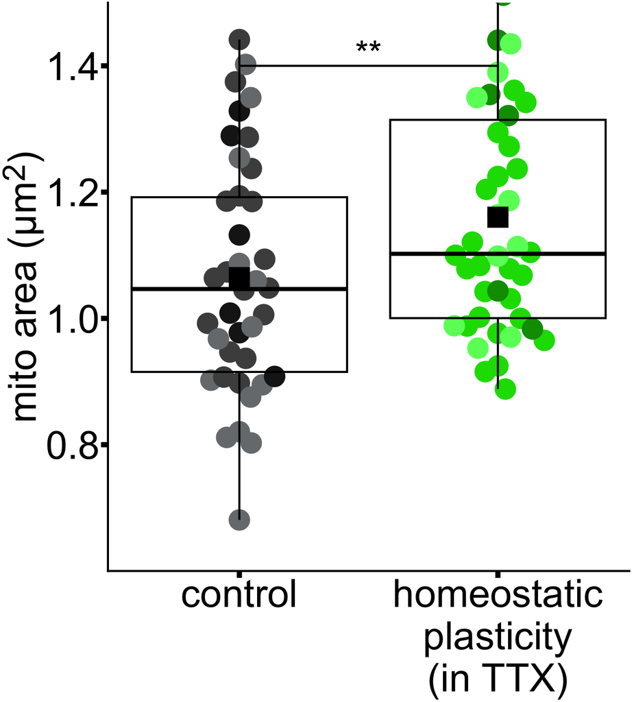

```r
set.seed(20261109)
date_levels <- levels(mito_df$Date)
date_colors <- c(
  setNames(rep(c("#4D4D4D", "#777B7E", "#1A1A1A"), length.out = length(date_levels)),
           paste("Control", date_levels, sep = "_")),
  setNames(rep(c("#00DC00", "#66FF66", "#009A00"), length.out = length(date_levels)),
           paste("TTXinTTX", date_levels, sep = "_"))
)
test_results <- tibble(
  group1_x = spacing_map["Control"], group2_x = spacing_map["TTXinTTX"],
  y_position = 1.4,
  stars = case_when(condition_p < 0.001 ~ "***", condition_p < 0.01 ~ "**",
                    condition_p < 0.05 ~ "*", TRUE ~ "ns")
) %>% filter(stars != "ns")

figs1g_plot <- ggplot(mito_df, aes(x_pos, mean_mito, color = Date_Condition)) +
  ggbeeswarm::geom_beeswarm(cex = 5, priority = "random", size = 20, corral = "random") +
  geom_boxplot(aes(group = x_pos), fill = NA, width = 1, outlier.shape = NA,
               linewidth = 2, color = "black") +
  stat_summary(aes(group = x_pos), fun = mean, geom = "point",
               shape = 15, size = 20, color = "black") +
  geom_segment(data = test_results,
               aes(x = group1_x, xend = group2_x, y = y_position, yend = y_position),
               inherit.aes = FALSE, linewidth = 2, color = "black") +
  geom_text(data = test_results,
            aes(x = (group1_x + group2_x) / 2, y = y_position + 0.02, label = stars),
            inherit.aes = FALSE, size = 25, color = "black") +
  scale_x_continuous(breaks = unname(spacing_map),
                     labels = c("control", "homeostatic\nplasticity\n(in TTX)")) +
  scale_color_manual(values = date_colors) +
  scale_y_continuous(oob = scales::oob_keep, breaks = c(0.8, 1.0, 1.2, 1.4),
                     limits = c(0.6, 1.5), expand = c(0, 0)) +
  labs(x = NULL, y = "mito area (&micro;m<sup>2</sup>)") +
  theme_classic() +
  theme(axis.title.y = ggtext::element_markdown(size = 80, color = "black"),
        axis.text = element_text(size = 80, color = "black"),
        axis.ticks = element_line(linewidth = 5, color = "black"),
        axis.ticks.length = grid::unit(0.5, "cm"),
        axis.line = element_line(linewidth = 2, color = "black"),
        legend.position = "none")
figs1g_plot
```

# Fig S1H

Dendritic mitochondrial length measured using endogenous PSD95 labeling with PSD95FingR-EGFP.

**Source data**  
`Fig S1H, I.csv`

**Columns**

- `Date` — Experiment date
- `Condition` — Control or TTX
- `Cell` — Cell ID
- `mean_mito_len` — Mean mitochondrial length per cell (µm)

## Data

```r
suppressPackageStartupMessages({
  library(dplyr); library(readr); library(ggplot2); library(ggbeeswarm)
})

spacing_map <- c(Control = 1, TTX = 2.2)
mito_df <- read_csv("./Fig S1H, I.csv", show_col_types = FALSE) %>%
  select(Date, Condition, Cell, mean_mito_len) %>%
  mutate(Date = trimws(as.character(Date)), Condition = trimws(as.character(Condition)),
         Condition = case_when(grepl("^Control", Condition, ignore.case = TRUE) ~ "Control",
                               grepl("^TTX", Condition, ignore.case = TRUE) ~ "TTX",
                               TRUE ~ Condition),
         mean_mito_len = as.numeric(mean_mito_len)) %>%
  filter(Condition %in% names(spacing_map), Date != "", !is.na(Cell),
         is.finite(mean_mito_len)) %>%
  mutate(Date = factor(Date), Condition = factor(Condition, levels = names(spacing_map)),
         Date_Condition = paste(Condition, Date, sep = "_"),
         x_pos = unname(spacing_map[as.character(Condition)]))

if (n_distinct(mito_df$Condition) < 2 || n_distinct(mito_df$Date) < 2)
  stop("Both conditions and at least two dates are required.")

mito_df %>% select(Date, Condition, Cell, mean_mito_len) %>%
  mutate(mean_mito_len = round(mean_mito_len, 3))
```

| Date | Condition | Cell | mean_mito_len |
| --- | --- | --- | --- |
| 2025-03-18 | Control | 7 | 7.772 |
| 2025-03-18 | Control | 12 | 7.185 |
| 2025-03-18 | Control | 18 | 7.116 |
| 2025-03-18 | Control | 19 | 4.653 |
| 2025-03-18 | Control | 20 | 4.241 |
| 2025-03-18 | TTX | 37 | 11.939 |
| 2025-03-18 | TTX | 38 | 6.105 |
| 2025-03-18 | TTX | 21 | 8.568 |
| 2025-03-18 | TTX | 22 | 5.008 |
| 2025-03-18 | TTX | 23 | 5.176 |

[output cut: 28 more lines]

## Summary

```r
summary_table <- mito_df %>% group_by(Condition) %>%
  summarise(n_Cells = n_distinct(Date, Cell), n_Experiment_Dates = n_distinct(Date),
            `Mean (SE)` = sprintf("%.3f (%.3f)", mean(mean_mito_len),
                                  sd(mean_mito_len) / sqrt(n())), .groups = "drop")
summary_table
```

| Condition | n_Cells | n_Experiment_Dates | Mean (SE) |
| --- | --- | --- | --- |
| Control | 20 | 3 | 5.570 (0.311) |
| TTX | 18 | 3 | 6.973 (0.474) |

## Statistics

Two-way ANOVA with condition, experiment date, and their interaction (Type I sums of squares).

```r
fit_aov <- aov(mean_mito_len ~ Condition * Date, data = mito_df)
condition_p <- as.numeric(anova(fit_aov)["Condition", "Pr(>F)"])
format_p <- function(p) ifelse(p < 0.0001, "<0.0001", sprintf("%.4f", p))

stats_table <- tibble(
  Test = "Two-way ANOVA", Comparison = "Control vs TTX",
  `Control mean (SE)` = summary_table$`Mean (SE)`[summary_table$Condition == "Control"],
  `TTX mean (SE)` = summary_table$`Mean (SE)`[summary_table$Condition == "TTX"],
  `Condition p` = format_p(condition_p)
)
stats_table
```

| Test | Comparison | Control mean (SE) | TTX mean (SE) | Condition p |
| --- | --- | --- | --- | --- |
| Two-way ANOVA | Control vs TTX | 5.570 (0.311) | 6.973 (0.474) | 0.0202 |

```r
anova(fit_aov)
```

|  | Df | Sum Sq | Mean Sq | F value | Pr(>F) |
| --- | --- | --- | --- | --- | --- |
| Condition | 1 | 18.646780 | 18.6467799 | 5.9744802 | 0.02020587 |
| Date | 2 | 4.591759 | 2.2958795 | 0.7356062 | 0.48714310 |
| Condition:Date | 2 | 0.909995 | 0.4549975 | 0.1457825 | 0.86491648 |
| Residuals | 32 | 99.874288 | 3.1210715 | NA | NA |

## Plot

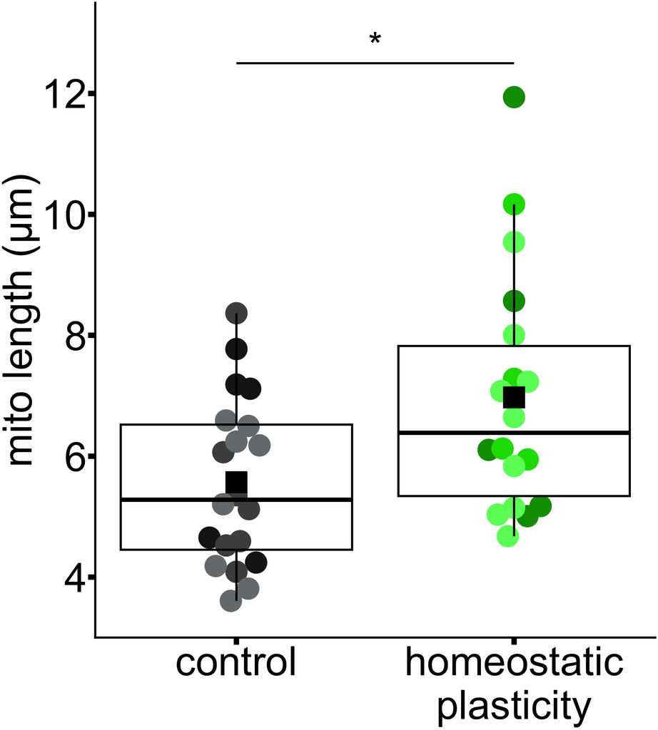

```r
set.seed(20261109)
date_levels <- levels(mito_df$Date)
date_colors <- c(
  setNames(rep(c("#1A1A1A", "#4D4D4D", "#777B7E"), length.out = length(date_levels)),
           paste("Control", date_levels, sep = "_")),
  setNames(rep(c("#009A00", "#00DC00", "#66FF66"), length.out = length(date_levels)),
           paste("TTX", date_levels, sep = "_"))
)
test_results <- tibble(
  group1_x = spacing_map["Control"], group2_x = spacing_map["TTX"], y_position = 12.5,
  stars = case_when(condition_p < 0.001 ~ "***", condition_p < 0.01 ~ "**",
                    condition_p < 0.05 ~ "*", TRUE ~ "ns")
) %>% filter(stars != "ns")

figs1h_plot <- ggplot(mito_df, aes(x_pos, mean_mito_len, color = Date_Condition)) +
  ggbeeswarm::geom_beeswarm(cex = 5, priority = "random", size = 20, corral = "random") +
  geom_boxplot(aes(group = x_pos), fill = NA, width = 1, outlier.shape = NA,
               linewidth = 2, color = "black") +
  stat_summary(aes(group = x_pos), fun = mean, geom = "point",
               shape = 15, size = 20, color = "black") +
  geom_segment(data = test_results,
               aes(x = group1_x, xend = group2_x, y = y_position, yend = y_position),
               inherit.aes = FALSE, linewidth = 2, color = "black") +
  geom_text(data = test_results,
            aes(x = (group1_x + group2_x) / 2, y = y_position + 0.3, label = stars),
            inherit.aes = FALSE, size = 25, color = "black") +
  scale_x_continuous(breaks = unname(spacing_map),
                     labels = c("control", "homeostatic\nplasticity")) +
  scale_color_manual(values = date_colors) +
  scale_y_continuous(oob = scales::oob_keep, breaks = c(4, 6, 8, 10, 12),
                     limits = c(3, 13.5), expand = c(0, 0)) +
  labs(x = NULL, y = "mito length (µm)") +
  theme_classic() +
  theme(axis.title = element_text(size = 80, color = "black"),
        axis.text = element_text(size = 80, color = "black"),
        axis.ticks = element_line(linewidth = 5, color = "black"),
        axis.ticks.length = grid::unit(0.5, "cm"),
        axis.line = element_line(linewidth = 2, color = "black"),
        legend.position = "none")
figs1h_plot
```

# Fig S1I

Juxtaspinal mitochondrial area measured using endogenous PSD95 labeling with PSD95FingR-EGFP.

**Source data**  
`Fig S1H, I.csv`

**Columns**

- `Date` — Experiment date
- `Condition` — Control or TTX
- `Cell` — Cell ID
- `mean_mito` — Mean juxtaspinal mitochondrial area per cell (µm²)

## Data

```r
suppressPackageStartupMessages({
  library(dplyr); library(readr); library(ggplot2); library(ggbeeswarm); library(ggtext)
})

spacing_map <- c(Control = 1, TTX = 2.2)
mito_df <- read_csv("./Fig S1H, I.csv", show_col_types = FALSE) %>%
  select(Date, Condition, Cell, mean_mito) %>%
  mutate(Date = trimws(as.character(Date)), Condition = trimws(as.character(Condition)),
         Condition = case_when(grepl("^Control", Condition, ignore.case = TRUE) ~ "Control",
                               grepl("^TTX", Condition, ignore.case = TRUE) ~ "TTX",
                               TRUE ~ Condition),
         mean_mito = as.numeric(mean_mito)) %>%
  filter(Condition %in% names(spacing_map), Date != "", !is.na(Cell),
         is.finite(mean_mito)) %>%
  mutate(Date = factor(Date), Condition = factor(Condition, levels = names(spacing_map)),
         Date_Condition = paste(Condition, Date, sep = "_"),
         x_pos = unname(spacing_map[as.character(Condition)]))

if (n_distinct(mito_df$Condition) < 2 || n_distinct(mito_df$Date) < 2)
  stop("Both conditions and at least two dates are required.")

mito_df %>% select(Date, Condition, Cell, mean_mito) %>%
  mutate(mean_mito = round(mean_mito, 3))
```

| Date | Condition | Cell | mean_mito |
| --- | --- | --- | --- |
| 2025-03-18 | Control | 7 | 0.926 |
| 2025-03-18 | Control | 12 | 1.129 |
| 2025-03-18 | Control | 18 | 0.942 |
| 2025-03-18 | Control | 19 | 0.849 |
| 2025-03-18 | Control | 20 | 0.975 |
| 2025-03-18 | TTX | 37 | 1.272 |
| 2025-03-18 | TTX | 38 | 0.971 |
| 2025-03-18 | TTX | 21 | 0.900 |
| 2025-03-18 | TTX | 22 | 0.959 |
| 2025-03-18 | TTX | 23 | 0.878 |

[output cut: 28 more lines]

## Summary

```r
summary_table <- mito_df %>% group_by(Condition) %>%
  summarise(n_Cells = n_distinct(Date, Cell), n_Experiment_Dates = n_distinct(Date),
            `Mean (SE)` = sprintf("%.3f (%.3f)", mean(mean_mito),
                                  sd(mean_mito) / sqrt(n())), .groups = "drop")
summary_table
```

| Condition | n_Cells | n_Experiment_Dates | Mean (SE) |
| --- | --- | --- | --- |
| Control | 20 | 3 | 0.970 (0.023) |
| TTX | 18 | 3 | 1.057 (0.026) |

## Statistics

Two-way ANOVA with condition, experiment date, and their interaction (Type I sums of squares).

```r
fit_aov <- aov(mean_mito ~ Condition * Date, data = mito_df)
condition_p <- as.numeric(anova(fit_aov)["Condition", "Pr(>F)"])
format_p <- function(p) ifelse(p < 0.0001, "<0.0001", sprintf("%.4f", p))

stats_table <- tibble(
  Test = "Two-way ANOVA", Comparison = "Control vs TTX",
  `Control mean (SE)` = summary_table$`Mean (SE)`[summary_table$Condition == "Control"],
  `TTX mean (SE)` = summary_table$`Mean (SE)`[summary_table$Condition == "TTX"],
  `Condition p` = format_p(condition_p)
)
stats_table
```

| Test | Comparison | Control mean (SE) | TTX mean (SE) | Condition p |
| --- | --- | --- | --- | --- |
| Two-way ANOVA | Control vs TTX | 0.970 (0.023) | 1.057 (0.026) | 0.0176 |

```r
anova(fit_aov)
```

|  | Df | Sum Sq | Mean Sq | F value | Pr(>F) |
| --- | --- | --- | --- | --- | --- |
| Condition | 1 | 0.07189734 | 0.071897342 | 6.2718147 | 0.01755677 |
| Date | 2 | 0.02161519 | 0.010807597 | 0.9427782 | 0.40009740 |
| Condition:Date | 2 | 0.01269583 | 0.006347917 | 0.5537473 | 0.58020115 |
| Residuals | 32 | 0.36683401 | 0.011463563 | NA | NA |

## Plot

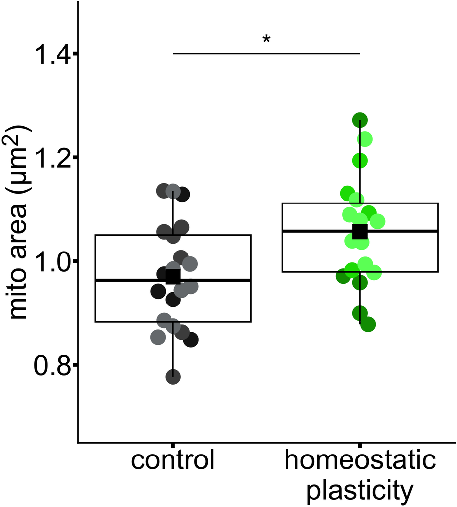

```r
set.seed(20261109)
date_levels <- levels(mito_df$Date)
date_colors <- c(
  setNames(rep(c("#1A1A1A", "#4D4D4D", "#777B7E"), length.out = length(date_levels)),
           paste("Control", date_levels, sep = "_")),
  setNames(rep(c("#009A00", "#00DC00", "#66FF66"), length.out = length(date_levels)),
           paste("TTX", date_levels, sep = "_"))
)
test_results <- tibble(
  group1_x = spacing_map["Control"], group2_x = spacing_map["TTX"], y_position = 1.4,
  stars = case_when(condition_p < 0.001 ~ "***", condition_p < 0.01 ~ "**",
                    condition_p < 0.05 ~ "*", TRUE ~ "ns")
) %>% filter(stars != "ns")

figs1i_plot <- ggplot(mito_df, aes(x_pos, mean_mito, color = Date_Condition)) +
  ggbeeswarm::geom_beeswarm(cex = 5, priority = "random", size = 20, corral = "random") +
  geom_boxplot(aes(group = x_pos), fill = NA, width = 1, outlier.shape = NA,
               linewidth = 2, color = "black") +
  stat_summary(aes(group = x_pos), fun = mean, geom = "point",
               shape = 15, size = 20, color = "black") +
  geom_segment(data = test_results,
               aes(x = group1_x, xend = group2_x, y = y_position, yend = y_position),
               inherit.aes = FALSE, linewidth = 2, color = "black") +
  geom_text(data = test_results,
            aes(x = (group1_x + group2_x) / 2, y = y_position + 0.02, label = stars),
            inherit.aes = FALSE, size = 25, color = "black") +
  scale_x_continuous(breaks = unname(spacing_map),
                     labels = c("control", "homeostatic\nplasticity")) +
  scale_color_manual(values = date_colors) +
  scale_y_continuous(oob = scales::oob_keep, breaks = c(0.8, 1.0, 1.2, 1.4),
                     limits = c(0.65, 1.5), expand = c(0, 0)) +
  labs(x = NULL, y = "mito area (&micro;m<sup>2</sup>)") +
  theme_classic() +
  theme(axis.title.y = ggtext::element_markdown(size = 80, color = "black"),
        axis.text = element_text(size = 80, color = "black"),
        axis.ticks = element_line(linewidth = 5, color = "black"),
        axis.ticks.length = grid::unit(0.5, "cm"),
        axis.line = element_line(linewidth = 2, color = "black"),
        legend.position = "none")
figs1i_plot
```

# Fig S1M

Static morphological signatures of juxtaspinal mitochondrial enlargement in somatosensory cortex.

**Source data**  
`Fig S1M.csv`

**Columns**

- `Morphology` — Recruitment, protrusion, budding, or no change
- `synapses` — Synapse count in the category
- `total_synapses` — Total synapse count

## Data

```r
suppressPackageStartupMessages({
  library(dplyr); library(readr); library(ggplot2)
})

category_order <- c("recruitment", "protrusion", "budding", "no change")
Pie <- read_csv("./Fig S1M.csv", show_col_types = FALSE) %>%
  transmute(Category = trimws(tolower(Morphology)),
            Value = as.numeric(synapses),
            total_synapses = as.numeric(total_synapses))

if (nrow(Pie) != 4 || anyDuplicated(Pie$Category) ||
    !setequal(Pie$Category, category_order))
  stop("Fig S1M.csv must contain each of the four morphology categories once.")
if (any(!is.finite(Pie$Value)) || n_distinct(Pie$total_synapses) != 1 ||
    sum(Pie$Value) != Pie$total_synapses[1])
  stop("Synapse counts must sum to the shared total_synapses value.")

Pie <- Pie %>%
  mutate(Category = factor(Category, levels = category_order)) %>%
  arrange(Category) %>%
  mutate(Percent = round(100 * Value / total_synapses),
         midpoint = cumsum(Value) - Value / 2)

Pie %>% select(Category, Value, total_synapses, Percent)
```

| Category | Value | total_synapses | Percent |
| --- | --- | --- | --- |
| recruitment | 24081 | 198563 | 12 |
| protrusion | 7990 | 198563 | 4 |
| budding | 4065 | 198563 | 2 |
| no change | 162427 | 198563 | 82 |

## Summary

```r
summary_table <- Pie %>% select(Category, Percent)
summary_table
```

| Category | Percent |
| --- | --- |
| recruitment | 12 |
| protrusion | 4 |
| budding | 2 |
| no change | 82 |

## Statistics

Descriptive counts and percentages.

## Plot

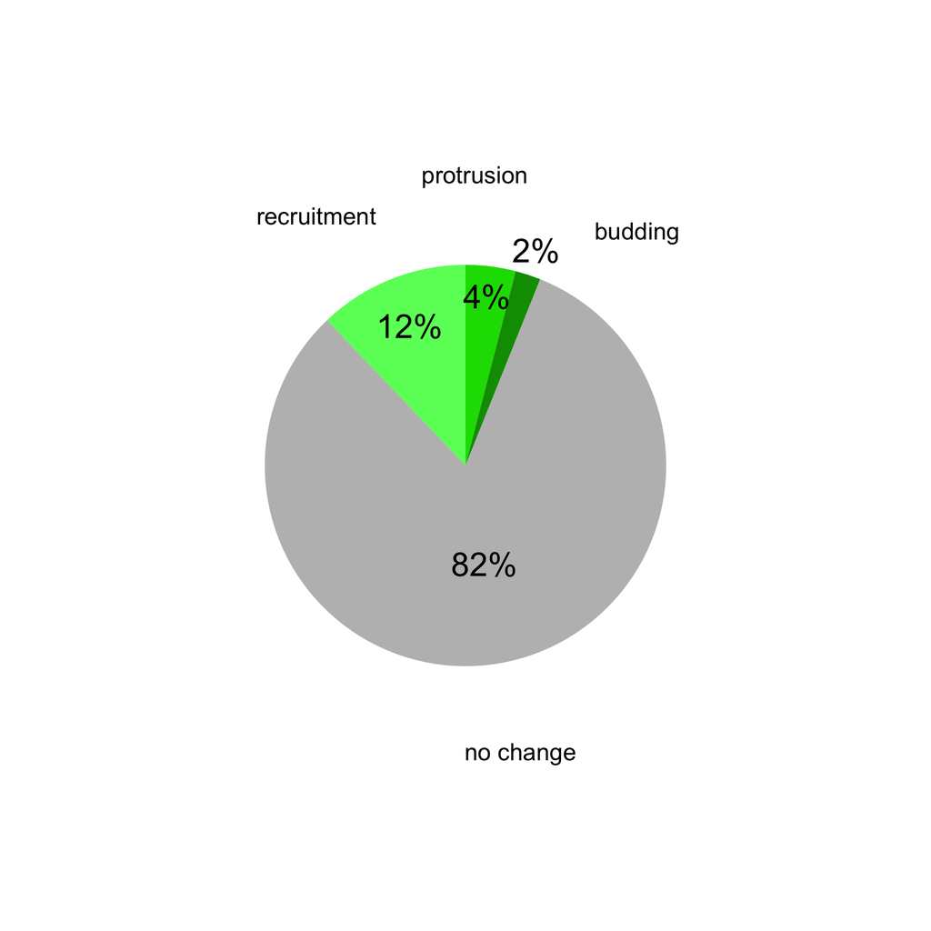

```r
set.seed(20261109)
fill_colors <- c(recruitment = "#66FF66", protrusion = "#00DC00",
                 budding = "#009A00", `no change` = "#BDBDBD")
start_angle <- -2 * pi * Pie$Value[Pie$Category == "recruitment"] / sum(Pie$Value)

pie_labels <- Pie %>% mutate(
  percent_x = case_when(Category == "recruitment" ~ 1.25,
                        Category == "protrusion" ~ 1.35,
                        Category == "budding" ~ 1.63, TRUE ~ 1),
  category_y = case_when(
    Category == "recruitment" ~ midpoint - 0.025 * sum(Value),
    Category == "protrusion" ~ midpoint - 0.015 * sum(Value),
    Category == "budding" ~ midpoint + 0.05 * sum(Value),
    TRUE ~ midpoint
  )
)

figs1m_plot <- ggplot(Pie, aes(x = 1, y = Value, fill = Category)) +
  geom_col(width = 1, linewidth = 0, position = position_stack(reverse = TRUE),
           show.legend = FALSE) +
  geom_text(data = pie_labels,
            aes(x = percent_x, y = midpoint, label = paste0(Percent, "%")),
            inherit.aes = FALSE, size = 18, color = "black") +
  geom_text(data = pie_labels,
            aes(x = 1.95, y = category_y, label = as.character(Category)),
            inherit.aes = FALSE, size = 13, color = "black") +
  scale_fill_manual(values = fill_colors, guide = "none") +
  scale_x_continuous(oob = scales::oob_keep, limits = c(0.5, 2.15), expand = c(0, 0)) +
  coord_polar(theta = "y", start = start_angle, direction = 1, clip = "off") +
  theme_void() +
  theme(plot.background = element_rect(fill = "white", color = NA),
        plot.margin = margin(40, 80, 40, 80))
figs1m_plot
```